# Heart disease

Argen Almazbek uulu

April 4, 2019

Context This database contains 76 attributes, but all published experiments refer to using a subset of 14 of them. In particular, the Cleveland database is the only one that has been used by ML researchers to this date. The “goal” field refers to the presence of heart disease in the patient. It is integer valued from 0 (no presence) to 4.

Content

Attribute Information: 1. age 2. sex 3. chest pain type (4 values) 4. resting blood pressure 5. serum cholestoral in mg/dl 6. fasting blood sugar > 120 mg/dl 7. resting electrocardiographic results (values 0,1,2) 8. maximum heart rate achieved 9. exercise induced angina 10. oldpeak = ST depression induced by exercise relative to rest 11. the slope of the peak exercise ST segment 12. number of major vessels (0-3) colored by flourosopy 13. thal: 3 = normal; 6 = fixed defect; 7 = reversable defect

The names and social security numbers of the patients were recently removed from the database, replaced with dummy values. One file has been “processed”, that one containing the Cleveland database. All four unprocessed files also exist in this directory.

To see Test Costs (donated by Peter Turney), please see the folder “Costs”

Acknowledgements Creators: 1. Hungarian Institute of Cardiology. Budapest: Andras Janosi, M.D. 2. University Hospital, Zurich, Switzerland: William Steinbrunn, M.D. 3. University Hospital, Basel, Switzerland: Matthias Pfisterer, M.D. 4. V.A. Medical Center, Long Beach and Cleveland Clinic Foundation: Robert Detrano, M.D., Ph.D.

Donor: David W. Aha (aha ‘@’ ics.uci.edu) (714) 856-8779

Inspiration Experiments with the Cleveland database have concentrated on simply attempting to distinguish presence (values 1,2,3,4) from absence (value 0).

See if you can find any other trends in heart data to predict certain cardiovascular events or find any clear indications of heart health.

```r
library(dplyr)
library(ggplot2)
library(tidyr)
library(caret)
library(corrplot)
```

```r
data <- read.csv('heart.csv', stringsAsFactors = F, encoding = 'UTF-8')
str(data)
```

```
## 'data.frame':    303 obs. of  14 variables:
##  $ X.U.FEFF.age: int  63 37 41 56 57 57 56 44 52 57 ...
##  $ sex         : int  1 1 0 1 0 1 0 1 1 1 ...
##  $ cp          : int  3 2 1 1 0 0 1 1 2 2 ...
##  $ trestbps    : int  145 130 130 120 120 140 140 120 172 150 ...
##  $ chol        : int  233 250 204 236 354 192 294 263 199 168 ...
##  $ fbs         : int  1 0 0 0 0 0 0 0 1 0 ...
##  $ restecg     : int  0 1 0 1 1 1 0 1 1 1 ...
##  $ thalach     : int  150 187 172 178 163 148 153 173 162 174 ...
##  $ exang       : int  0 0 0 0 1 0 0 0 0 0 ...
##  $ oldpeak     : num  2.3 3.5 1.4 0.8 0.6 0.4 1.3 0 0.5 1.6 ...
##  $ slope       : int  0 0 2 2 2 1 1 2 2 2 ...
##  $ ca          : int  0 0 0 0 0 0 0 0 0 0 ...
##  $ thal        : int  1 2 2 2 2 1 2 3 3 2 ...
##  $ target      : int  1 1 1 1 1 1 1 1 1 1 ...
```

```r
colnames(data)[1] <- 'age'
str(data)
```

```
## 'data.frame':    303 obs. of  14 variables:
##  $ age     : int  63 37 41 56 57 57 56 44 52 57 ...
##  $ sex     : int  1 1 0 1 0 1 0 1 1 1 ...
##  $ cp      : int  3 2 1 1 0 0 1 1 2 2 ...
##  $ trestbps: int  145 130 130 120 120 140 140 120 172 150 ...
##  $ chol    : int  233 250 204 236 354 192 294 263 199 168 ...
##  $ fbs     : int  1 0 0 0 0 0 0 0 1 0 ...
##  $ restecg : int  0 1 0 1 1 1 0 1 1 1 ...
##  $ thalach : int  150 187 172 178 163 148 153 173 162 174 ...
##  $ exang   : int  0 0 0 0 1 0 0 0 0 0 ...
##  $ oldpeak : num  2.3 3.5 1.4 0.8 0.6 0.4 1.3 0 0.5 1.6 ...
##  $ slope   : int  0 0 2 2 2 1 1 2 2 2 ...
##  $ ca      : int  0 0 0 0 0 0 0 0 0 0 ...
##  $ thal    : int  1 2 2 2 2 1 2 3 3 2 ...
##  $ target  : int  1 1 1 1 1 1 1 1 1 1 ...
```

```r
##Let's check for the missing values
sapply(data, function(X) sum(is.na(X)))
```

```
##      age      sex       cp trestbps     chol      fbs  restecg  thalach
##        0        0        0        0        0        0        0        0
##    exang  oldpeak    slope       ca     thal   target
##        0        0        0        0        0        0
```

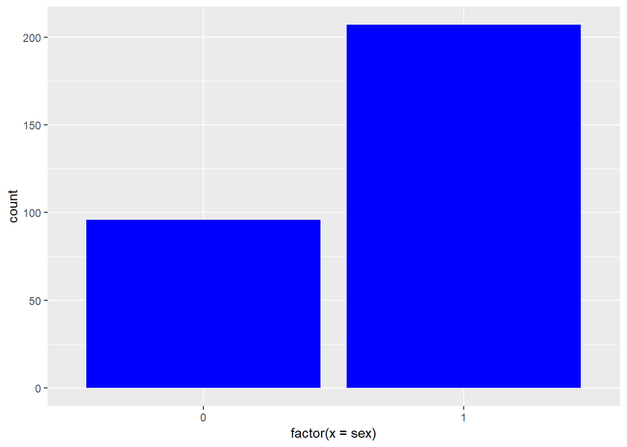

```r
##Let's get the intuition of how many males and females are there in a dataset
ggplot(data, aes(x = factor(x = sex))) + geom_bar(fill ='blue')
```

```r
## Here is the numbers of males and females (females = 0, males = 1)
data %>%
  group_by(sex) %>%
  summarize(n())
```

```
## # A tibble: 2 x 2
##     sex `n()`
##   <int> <int>
## 1     0    96
## 2     1   207
```

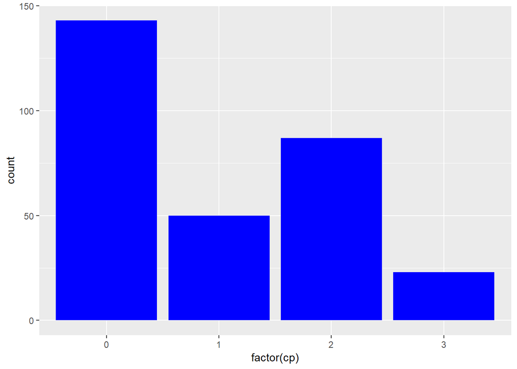

```r
## Now let's see the distribution of Chest Pain Type variable
ggplot(data, aes(x = factor(cp))) + geom_bar(fill = 'blue')
```

```r
## Age to target
data$age[data$age == 29] <- 31
AgeBins <- paste(seq(30,80,10),"'d")
data$age.B <- cut(data$age, seq(30,90,10),labels = AgeBins)
table(data$age.B, useNA = "always")
```

```
##
## 30 'd 40 'd 50 'd 60 'd 70 'd 80 'd  <NA>
##    19    76   129    73     6     0     0
```

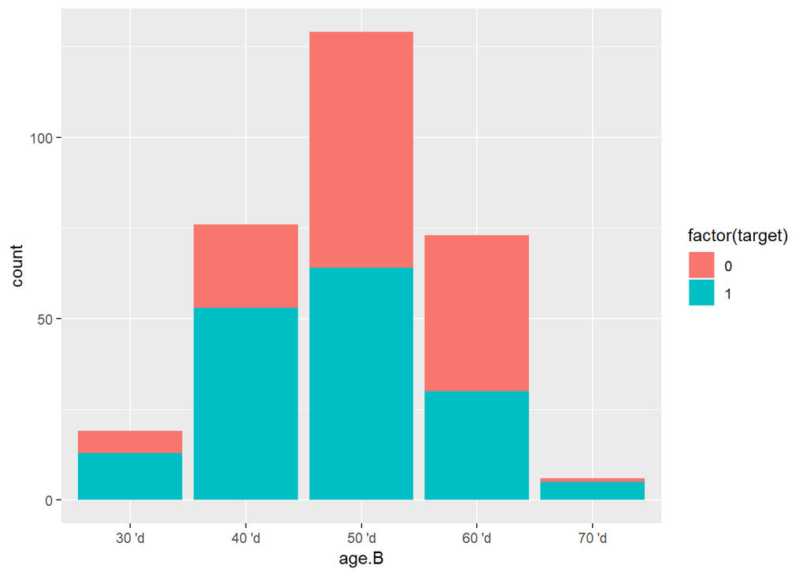

```r
ggplot(data=data, aes(x=age.B,fill=factor(target))) + geom_bar()
```

```r
## Resting blood preasure
summary(data$trestbps)
```

```
##    Min. 1st Qu.  Median    Mean 3rd Qu.    Max.
##    94.0   120.0   130.0   131.6   140.0   200.0
```

```r
summary(data$age)
```

```
##    Min. 1st Qu.  Median    Mean 3rd Qu.    Max.
##   31.00   47.50   55.00   54.37   61.00   77.00
```

```r
summary(data$chol)
```

```
##    Min. 1st Qu.  Median    Mean 3rd Qu.    Max.
##   126.0   211.0   240.0   246.3   274.5   564.0
```

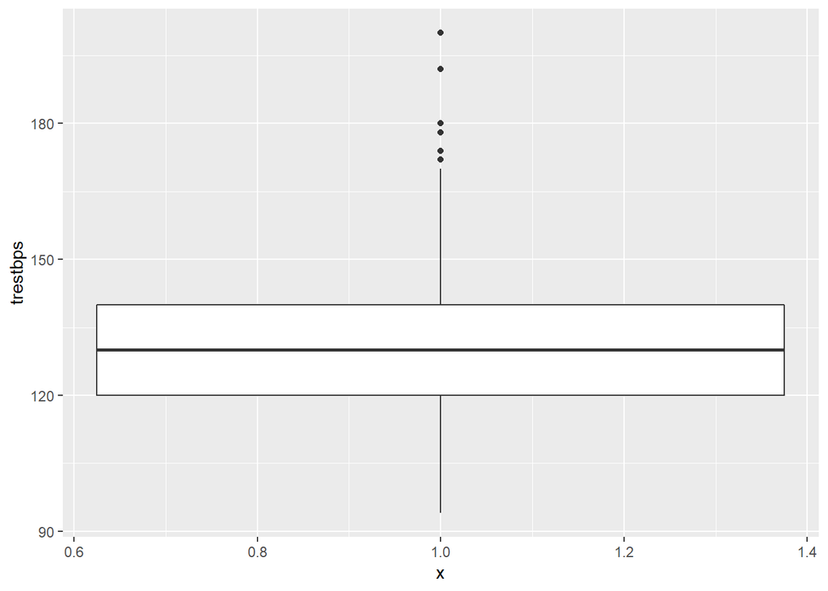

```r
ggplot(data, aes(x = 1, y = trestbps)) + geom_boxplot()
```

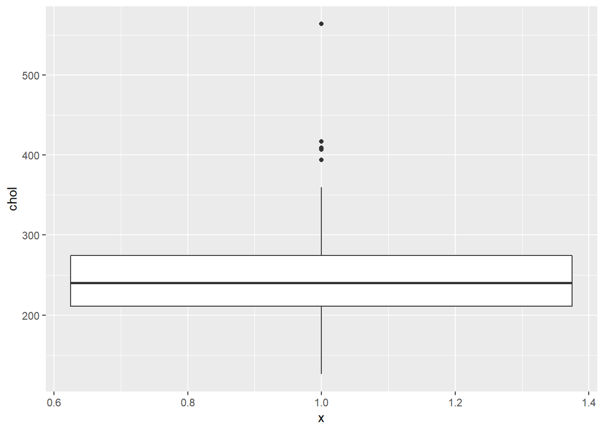

```r
ggplot(data, aes(x = 1, y = chol)) + geom_boxplot()
```

# Feature Transformation

```r
ifelse(data$sex==0, 'female', 'male' )
```

[output not shown]

[output cut: 29 more lines]

```r
data$sex <- as.factor(data$sex)
colnames(data)[3] <- 'chest_pain_type'
colnames(data)[4] <-'resting_blood_preasure'
colnames(data)[6] <- 'fasting_blood_sugar'
colnames(data)[8] <- 'max_heart_rate'
colnames(data)[9] <- 'excercise_induced_angina'
colnames(data)[13] <- 'thalassemia'
data$chest_pain_type <- as.factor(data$chest_pain_type)
data$fasting_blood_sugar <- as.factor(data$fasting_blood_sugar)
data$restecg <- as.factor(data$restecg)
```

# First Logistic Regression

```r
data$target <- as.factor(data$target)
set.seed(1997)

features <- data %>% select(target, age.B, chest_pain_type, sex, resting_blood_preasure, chol, fasting_blood_sugar, restecg, max_heart_rate, thalassemia, excercise_induced_angina, oldpeak, slope, ca)
str(features)
```

```
## 'data.frame':    303 obs. of  14 variables:
##  $ target                  : Factor w/ 2 levels "0","1": 2 2 2 2 2 2 2 2 2 2 ...
##  $ age.B                   : Factor w/ 6 levels "30 'd","40 'd",..: 4 1 2 3 3 3 3 2 3 3 ...
##  $ chest_pain_type         : Factor w/ 4 levels "0","1","2","3": 4 3 2 2 1 1 2 2 3 3 ...
##  $ sex                     : Factor w/ 2 levels "0","1": 2 2 1 2 1 2 1 2 2 2 ...
##  $ resting_blood_preasure  : int  145 130 130 120 120 140 140 120 172 150 ...
##  $ chol                    : int  233 250 204 236 354 192 294 263 199 168 ...
##  $ fasting_blood_sugar     : Factor w/ 2 levels "0","1": 2 1 1 1 1 1 1 1 2 1 ...
##  $ restecg                 : Factor w/ 3 levels "0","1","2": 1 2 1 2 2 2 1 2 2 2 ...
##  $ max_heart_rate          : int  150 187 172 178 163 148 153 173 162 174 ...
##  $ thalassemia             : int  1 2 2 2 2 1 2 3 3 2 ...
##  $ excercise_induced_angina: int  0 0 0 0 1 0 0 0 0 0 ...
##  $ oldpeak                 : num  2.3 3.5 1.4 0.8 0.6 0.4 1.3 0 0.5 1.6 ...
##  $ slope                   : int  0 0 2 2 2 1 1 2 2 2 ...
##  $ ca                      : int  0 0 0 0 0 0 0 0 0 0 ...
```

```r
sample_size <- floor(0.75*nrow(features))
sample_size
```

```
## [1] 227
```

```r
data_ind <- sample(seq_len(nrow(features)), size = sample_size)
head(data_ind, n=10)
```

```
##  [1]  68 191 247 228  41 188 136 265  13 100
```

```r
data_sample <- features[data_ind,]
data_val <- features[-data_ind,]
labels_val <- data_val$target
data_val$target <- NULL



reg <- glm(target ~ ., data = features, family = binomial())
summary(reg)
```

```
##
## Call:
## glm(formula = target ~ ., family = binomial(), data = features)
##
## Deviance Residuals:
##     Min       1Q   Median       3Q      Max
## -2.6132  -0.3724   0.1474   0.5744   2.6179
##
## Coefficients:
##                           Estimate Std. Error z value Pr(>|z|)
## (Intercept)               2.659577   2.438690   1.091 0.275459
## age.B40 'd                0.045875   0.832111   0.055 0.956034
## age.B50 'd                0.146903   0.800766   0.183 0.854443
## age.B60 'd                0.218395   0.875583   0.249 0.803029
## age.B70 'd                1.789321   1.870670   0.957 0.338813
## chest_pain_type1          1.112659   0.553627   2.010 0.044456 *
## chest_pain_type2          2.028315   0.467533   4.338 1.44e-05 ***
## chest_pain_type3          2.115830   0.637893   3.317 0.000910 ***
## sex1                     -1.684767   0.479989  -3.510 0.000448 ***
## resting_blood_preasure   -0.018554   0.010594  -1.751 0.079889 .
## chol                     -0.005285   0.003956  -1.336 0.181625
## fasting_blood_sugar1     -0.030832   0.546586  -0.056 0.955017
## restecg1                  0.520793   0.367050   1.419 0.155940
## restecg2                 -1.056339   3.312574  -0.319 0.749812
## max_heart_rate            0.024694   0.010541   2.343 0.019139 *
## thalassemia              -0.880135   0.295832  -2.975 0.002929 **
## excercise_induced_angina -0.928087   0.426938  -2.174 0.029719 *
## oldpeak                  -0.491957   0.222043  -2.216 0.026719 *
## slope                     0.552916   0.356740   1.550 0.121162
## ca                       -0.821812   0.197086  -4.170 3.05e-05 ***
## ---
## Signif. codes:  0 '***' 0.001 '**' 0.01 '*' 0.05 '.' 0.1 ' ' 1
##
## (Dispersion parameter for binomial family taken to be 1)
##
##     Null deviance: 417.64  on 302  degrees of freedom
## Residual deviance: 208.21  on 283  degrees of freedom
## AIC: 248.21
##
## Number of Fisher Scoring iterations: 6
```

```r
preds <- predict(reg, newdata = data_val, type = "response")

confusionMatrix(as.factor(as.numeric(preds > 0.5)), labels_val)
```

```
## Confusion Matrix and Statistics
##
##           Reference
## Prediction  0  1
##          0 27  4
##          1 10 35
##
##                Accuracy : 0.8158
##                  95% CI : (0.7103, 0.8955)
##     No Information Rate : 0.5132
##     P-Value [Acc > NIR] : 4.062e-08
##
##                   Kappa : 0.6298
##  Mcnemar's Test P-Value : 0.1814
##
##             Sensitivity : 0.7297
##             Specificity : 0.8974
##          Pos Pred Value : 0.8710
##          Neg Pred Value : 0.7778
##              Prevalence : 0.4868
##          Detection Rate : 0.3553
##    Detection Prevalence : 0.4079
##       Balanced Accuracy : 0.8136
##
##        'Positive' Class : 0
##
```

```r
head(data_val$target)
```

[output not shown]

```r
head(as.numeric(preds > 0.5))
```

```
## [1] 1 1 1 1 1 1
```

# Correlation matrix

```r
correlations <- cor(data[,c(1,5,4,8)])
correlations
```

```
##                               age         chol resting_blood_preasure
## age                     1.0000000  0.213501507             0.27983145
## chol                    0.2135015  1.000000000             0.12317421
## resting_blood_preasure  0.2798314  0.123174207             1.00000000
## max_heart_rate         -0.3976341 -0.009939839            -0.04669773
##                        max_heart_rate
## age                      -0.397634050
## chol                     -0.009939839
## resting_blood_preasure   -0.046697728
## max_heart_rate            1.000000000
```

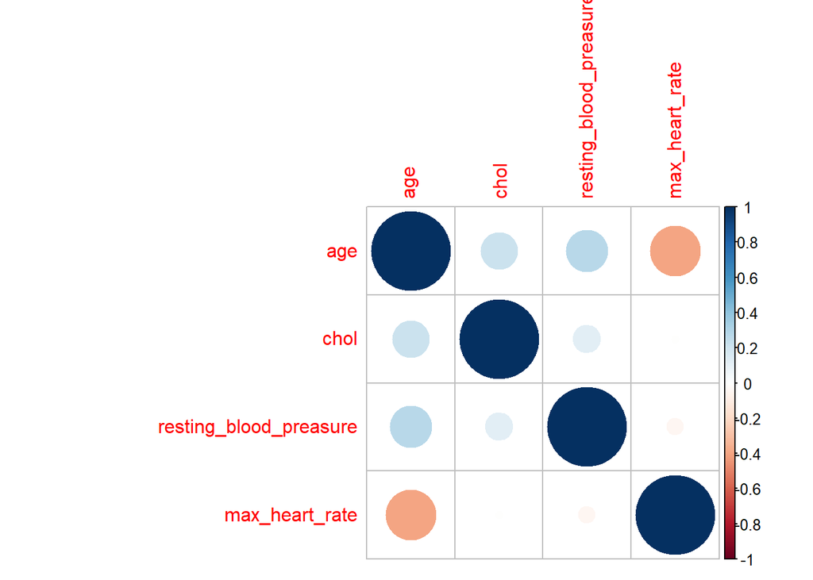

```r
corrplot(correlations)
```

# Second Regression

```r
features2 <- data %>% select(target, chest_pain_type, sex, resting_blood_preasure, max_heart_rate, thalassemia, excercise_induced_angina, oldpeak, ca)
reg <- glm(target ~ ., data = features2, family = binomial())
summary(reg)
```

```
##
## Call:
## glm(formula = target ~ ., family = binomial(), data = features2)
##
## Deviance Residuals:
##     Min       1Q   Median       3Q      Max
## -2.5163  -0.4511   0.1777   0.5783   2.5358
##
## Coefficients:
##                           Estimate Std. Error z value Pr(>|z|)
## (Intercept)               2.591060   1.890648   1.370 0.170543
## chest_pain_type1          1.156900   0.527290   2.194 0.028232 *
## chest_pain_type2          1.982868   0.444619   4.460 8.21e-06 ***
## chest_pain_type3          2.029393   0.615190   3.299 0.000971 ***
## sex1                     -1.493775   0.423993  -3.523 0.000427 ***
## resting_blood_preasure   -0.019525   0.009758  -2.001 0.045406 *
## max_heart_rate            0.025345   0.009135   2.774 0.005529 **
## thalassemia              -0.891292   0.280897  -3.173 0.001509 **
## excercise_induced_angina -0.912521   0.405186  -2.252 0.024316 *
## oldpeak                  -0.663585   0.193021  -3.438 0.000586 ***
## ca                       -0.714377   0.177802  -4.018 5.87e-05 ***
## ---
## Signif. codes:  0 '***' 0.001 '**' 0.01 '*' 0.05 '.' 0.1 ' ' 1
##
## (Dispersion parameter for binomial family taken to be 1)
##
##     Null deviance: 417.64  on 302  degrees of freedom
## Residual deviance: 216.94  on 292  degrees of freedom
## AIC: 238.94
##
## Number of Fisher Scoring iterations: 6
```

```r
preds2 <- predict(reg, newdata = data_val, type = "response")

confusionMatrix(as.factor(as.numeric(preds2 > 0.5)), labels_val)
```

```
## Confusion Matrix and Statistics
##
##           Reference
## Prediction  0  1
##          0 28  3
##          1  9 36
##
##                Accuracy : 0.8421
##                  95% CI : (0.7404, 0.9157)
##     No Information Rate : 0.5132
##     P-Value [Acc > NIR] : 1.941e-09
##
##                   Kappa : 0.6827
##  Mcnemar's Test P-Value : 0.1489
##
##             Sensitivity : 0.7568
##             Specificity : 0.9231
##          Pos Pred Value : 0.9032
##          Neg Pred Value : 0.8000
##              Prevalence : 0.4868
##          Detection Rate : 0.3684
##    Detection Prevalence : 0.4079
##       Balanced Accuracy : 0.8399
##
##        'Positive' Class : 0
##
```